# Road Clustering

## Load necessary packages and CSV files

```
import pandas as pd
```

```
import numpy as np
```

```
from scipy.spatial.distance import pdist, squareform
```

```
from scipy.cluster.hierarchy import linkage, dendrogram
```

```
from scipy.cluster.vq import kmeans, vq
```

```
import scipy.cluster.hierarchy as hac
```

```
import matplotlib.pyplot as plt
```

```
from pandas import Series, DataFrame
```

```
from collections import Counter
```

```
import glob
```

```
import csv
```

```
from pylab import plot,show
```

```
%matplotlib inline
```

```
# create empty lists to load data into
```

```
dataLists = []
```

```
pairs = []
```

```
# read data
```

```
allfiles = glob.glob("*.csv")
```

```
for files in allfiles:
```

```
    df=pd.read_csv(files, sep=";", header = 0)
```

```
    df.columns=['TimeOfDay', 'AntennaSeconds']
```

```
    dataLists.append(df) # load dataframes as lists
```

```
    pairs.append(files) # load file names
```

```
final = pd.DataFrame(pairs) # create dataframe with file names. Will be used to load cluster assignments into.
```

## Plot each CSV file to take a look at the different patterns

```
i = 0
```

```
for df in dataLists:
```

```
    plt.figure(figsize=(5,3))
```

```
    plt.scatter(df['TimeOfDay'], df['AntennaSeconds'], s=1)
```

```
    plt.title(pairs[i])
```

```
    i+=1
```

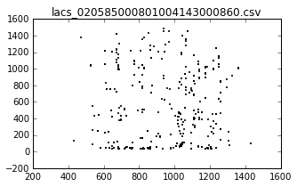

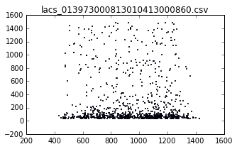

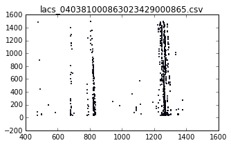

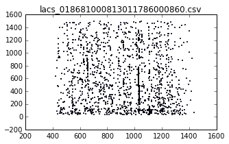

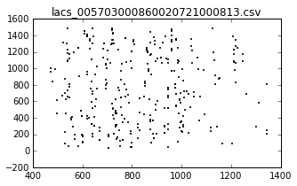

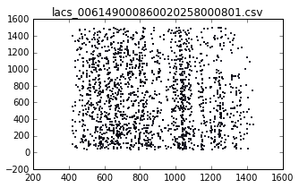

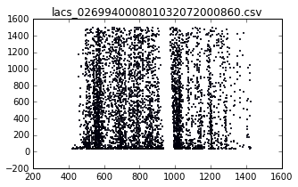

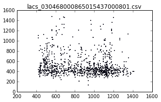

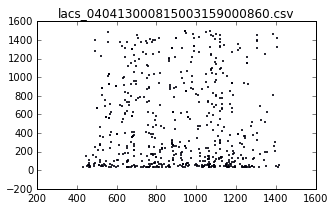

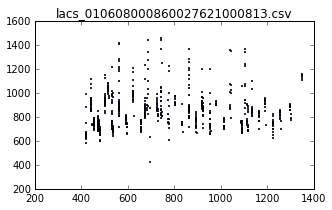

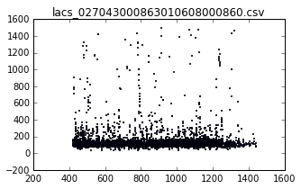

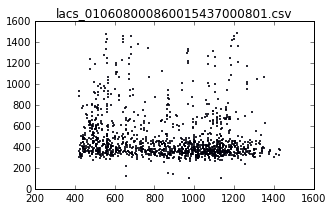

[38 more figures not shown]

## Plot each CSV file as boxplot to take a look at how the data is distributed.

#### Boxplots are a great way to understand how data is distributed. When compared against the scatterplots of the data, patterns start to emerge. Roads tend to have lower means as well as a tighter range between the first quartile and second quartile vs the second quartile and third quartile.

```
totfigs=len(allfiles)
```

```
plt.figure(figsize=(20,20))
```

```
plt.hold=True
```

```
boxes=[]
```

```
labels=list(pairs)
```

```
for df in dataLists:
```

```
    boxes.append(np.array(df['AntennaSeconds']))
```

```
plt.boxplot(boxes, vert=0, labels=labels)
```

```
plt.show()
```

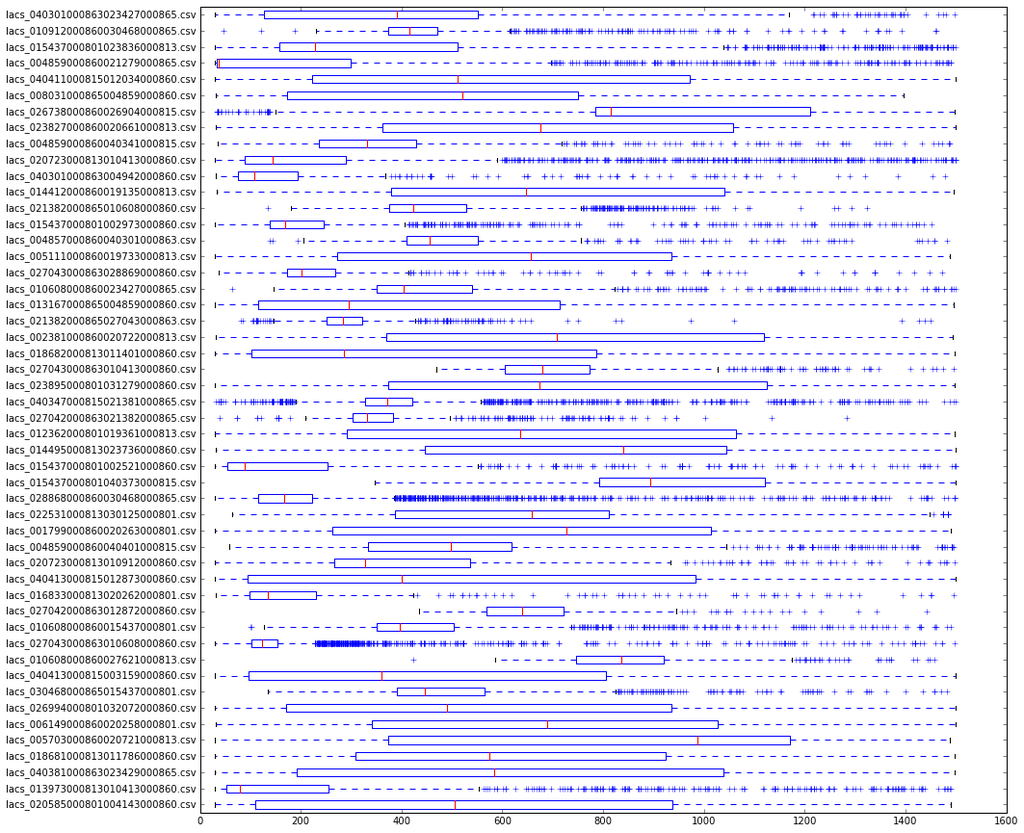

## Create variables to describe each CSV file in order to create a single 50 row dataset in order to better cluster the antenna pairs.

```
meannumber=[]
```

```
fqrange=[]
```

```
# Find mean for each dataset
```

```
for df in dataLists:
```

```
    meannumber.append((df['AntennaSeconds']).mean())
```

```
# Find the first quartile
```

```
for df in dataLists:
```

```
    fq = np.array(df['AntennaSeconds'])
```

```
    p=np.percentile(fq,25)
```

```
    fqrange.append(p)
```

```
# Find the range between the mean and the first quartile.
```

```
#The lower the number, the tighter the distribution in the lower end of the graph.
```

```
from operator import sub
```

```
c = map(sub, meannumber,fqrange)
```

```
# Create 50 row lists with the variables
```

```
final['AntennaPair']=pairs
```

```
final['mean'] = meannumber
```

```
final['fqrange'] = c
```

```
#Put the lists together into the dataframe
```

```
final1 = final.drop(0,1)
```

```
final2=final1.set_index('AntennaPair')
```

# First Attempt: Use Hierarchical Clustering to try to find clusters without having to specify the number of clusters.

```
fig, axes23 = plt.subplots(2, 3)
```

```
a = np.array(final2)
```

```
for method, axes in zip(['single', 'complete'], axes23):
```

```
    z = hac.linkage(a, method=method)
```

```
    # Plotting
```

```
    axes[0].plot(range(1, len(z)+1), z[::-1, 2])
```

```
    knee = np.diff(z[::-1, 2], 2)
```

```
    axes[0].plot(range(2, len(z)), knee)
```

```
    num_clust1 = knee.argmax() + 2
```

```
    knee[knee.argmax()] = 0
```

```
    num_clust2 = knee.argmax() + 2
```

```
    axes[0].text(num_clust1, z[::-1, 2][num_clust1-1], 'possible\n<- knee point')
```

```
    part1 = hac.fcluster(z, num_clust1, 'maxclust')
```

```
    part2 = hac.fcluster(z, num_clust2, 'maxclust')
```

```
    clr = ['#2200CC' ,'#D9007E' ,'#FF6600' ,'#FFCC00' ,'#ACE600' ,'#0099CC' ,
```

```
    '#8900CC' ,'#FF0000' ,'#FF9900' ,'#FFFF00' ,'#00CC01' ,'#0055CC']
```

```
    for part, ax in zip([part1, part2], axes[1:]):
```

```
        for cluster in set(part):
```

```
            ax.scatter(a[part == cluster, 0], a[part == cluster, 1],
```

```
                       color=clr[cluster])
```

```
    m = '\n(method: {})'.format(method)
```

```
    plt.setp(axes[0], title='Knee Plot{}'.format(m), xlabel='partition',
```

```
             ylabel='{}\ncluster distance'.format(m))
```

```
    plt.setp(axes[1], title='{} Clusters'.format(num_clust1))
```

```
    plt.setp(axes[2], title='{} Clusters'.format(num_clust2))
```

```
# Print the assigned cluster numbers for the 2-cluster graph
```

```
print part1, Counter(part1)
```

```
# Plot the graphs
```

```
plt.tight_layout()
```

```
plt.show()
```

```
[2 1 2 2 2 2 2 1 2 2 1 1 2 1 2 1 1 2 2 1 2 1 2 2 1 1 2 2 2 2 1 2 1 1 2 1 1
 1 2 1 1 1 2 2 2 2 1 1 1 1] Counter({2: 26, 1: 24})
```

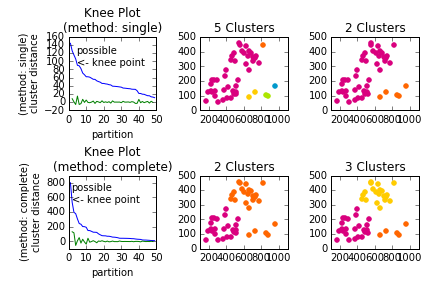

```
data_dist = pdist(a)
```

```
data_link=linkage(data_dist)
```

```
dendrogram(data_link, labels=a.dtype.names)
```

```
plt.xlabel('Samples')
```

```
plt.ylabel('Distance')
```

```
plt.suptitle('Samples Hierarchical Clustering', fontweight='bold', fontsize=14)
```

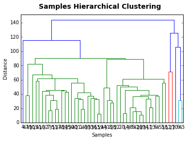

```
# Compute and plot first dendrogram.
```

```
fig = plt.figure(figsize=(8,8))
```

```
# x ywidth height
```

```
ax1 = fig.add_axes([0.05,0.1,0.2,0.6])
```

```
Y = linkage(data_dist, method='complete')
```

```
Z1 = dendrogram(Y, orientation='right',labels=a.dtype.names) # adding/removing the axes
```

```
ax1.set_xticks([])
```

```
# Compute and plot second dendrogram.
```

```
ax2 = fig.add_axes([0.3,0.71,0.6,0.2])
```

```
Z2 = dendrogram(Y)
```

```
ax2.set_xticks([])
```

```
ax2.set_yticks([])
```

```
#Compute and plot the heatmap
```

```
axmatrix = fig.add_axes([0.3,0.1,0.6,0.6])
```

```
idx1 = Z1['leaves']
```

```
idx2 = Z2['leaves']
```

```
D = squareform(data_dist)
```

```
D = D[idx1,:]
```

```
D = D[:,idx2]
```

```
im = axmatrix.matshow(D, aspect='auto', origin='lower', cmap=plt.cm.YlGnBu)
```

```
axmatrix.set_xticks([])
```

```
axmatrix.set_yticks([])
```

```
# Plot colorbar.
```

```
axcolor = fig.add_axes([0.91,0.1,0.02,0.6])
```

```
plt.colorbar(im, cax=axcolor)
```

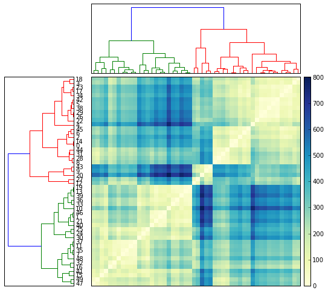

The heatmap shows that there is strong yellow along the diagonal but it appears that there are smaller subclusters within the two larger clusters.

Hierarchical Clustering based on average and range of the first quartile to second quartile resulted in two clusters of 24 and 26 pairs of antennas. As it was stated in class that there are 25 roads, this is not the optimal solution.

## Plot the cluster with the 26 points to see which road wasn't grouped in the cluster with the roads.

```
final2['cluster']=part1
```

```
finalgraphlist2=[]
```

```
dataLists3=[]
```

```
for i in range(len(final2)):
```

```
    if final2['cluster'][i]==2: #1 equals to roads, 2 equals to other
```

```
        finalgraphlist2.append((final2.index)[i])
```

```
for each in finalgraphlist2:
```

```
    df3=pd.read_csv(each, sep=";", header = 0)
```

```
    df3.columns=['TimeOfDay', 'AntennaSeconds']
```

```
    dataLists3.append(df3)
```

```
for df3 in dataLists3:
```

```
    plt.figure(figsize=(5,3))
```

```
    plt.scatter(df3['TimeOfDay'], df3['AntennaSeconds'], s=1)
```

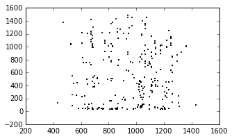

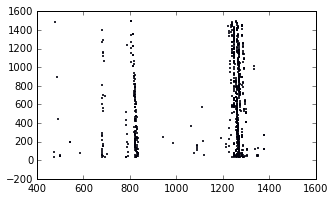

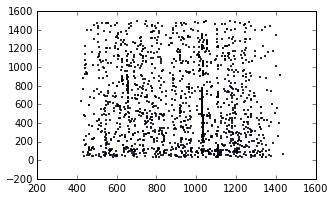

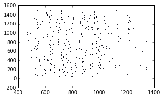

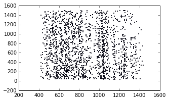

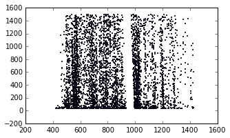

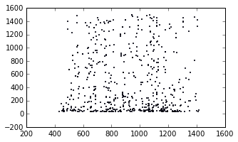

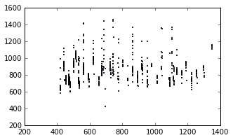

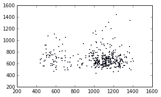

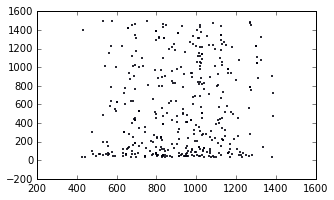

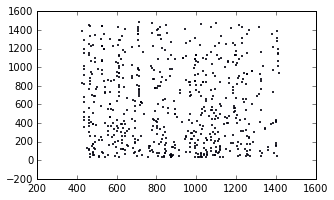

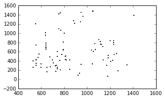

[14 more figures not shown]

The second last plot: lacs_008031000865004859000860.csv appears to be a road. However it also looks like there is noise in the data due to some other activity that the antennas are catching. In class, it was noted that straight vertical lines could be trains so perhaps there is some potential early morning train activity (i.e cargo trains). When looking at the other road graphs, it appears that quite a few of them also have some anomalous activities in the morning so the next attempt will choose a time frame with consistent patterning to try to avoid the noisy data.

# Second Attempt: K-Means

## Create variables to describe each CSV files in order to create a single 50 row dataset in order to better cluster the antenna pairs.

The variables are the same as in attempt one except they were only calculated on the data after 750 minutes (around 12:30pm) giving enough time for morning activities to stabilize. This is based purely on assumption. For a better model, a more expert opinion would be needed to identify what an actual road is and to consult on what would be a representative time frame or if time is even a factor in this model.

```
meannumber=[]
```

```
fqrange=[]
```

```
dataLists1 =[]
```

```
dataLists2=[]
```

```
#set timeframe for after the morning (12:30pm)
```

```
for df in dataLists:
```

```
    df=df[df['TimeOfDay']>750]
```

```
    dataLists1.append(df)
```

```
dataLists=dataLists1
```

```
#Find mean of each dataset
```

```
for df in dataLists:
```

```
    meannumber.append((df['AntennaSeconds']).mean())
```

```
#Find Q1 for each dataset
```

```
for df in dataLists:
```

```
    fq = np.array(df['AntennaSeconds'])
```

```
    p=np.percentile(fq,25)
```

```
    fqrange.append(p)
```

```
#Find the range from mean to Q1
```

```
from operator import sub
```

```
c = map(sub, meannumber,fqrange)
```

```
#Create dataframe
```

```
final['AntennaPair']=pairs
```

```
final['mean'] = meannumber
```

```
final['fqrange'] = c
```

```
final1 = final.drop(0,1)
```

```
final4=final1.set_index('AntennaPair')
```

```
final4.head()
```

| AntennaPair | mean | fqrange |
| --- | --- | --- |
| lacs_020585000801004143000860.csv | 554.900316 | 428.900316 |
| lacs_013973000813010413000860.csv | 257.775510 | 204.775510 |
| lacs_040381000863023429000865.csv | 643.430647 | 433.430647 |
| lacs_018681000813011786000860.csv | 611.830298 | 297.830298 |
| lacs_005703000860020721000813.csv | 837.800699 | 444.050699 |

## Use K-Means to divide data into 2 clusters (ideally roads and non-roads)

```
import matplotlib
```

```
#matplotlib.use('Agg')
```

```
from scipy.cluster.vq import *
```

```
import pylab
```

```
pylab.close()
```

```
b = np.array(final4)
```

```
#computing kmeans with k=2 (2 clusters)
```

```
centroids,_=kmeans(b,2)
```

```
#assign each sample to a cluster
```

```
idx,_=vq(b,centroids)
```

```
print idx, Counter(idx)
```

```
plot(b[idx==0,0],b[idx==0,1],'ob', b[idx==1,0],b[idx==1,1], 'or')
```

```
plot(centroids[:,0],centroids[:,1],'sg',markersize=8)
```

```
show()
```

```
[0 1 0 0 0 0 0 1 0 0 1 1 0 1 0 1 1 0 0 1 0 1 0 0 1 1 0 0 0 0 1 0 1 1 0 1 1
 1 0 1 1 1 0 0 1 0 1 1 1 1] Counter({0: 25, 1: 25})
```

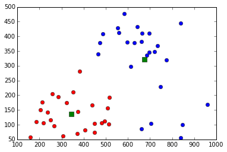

## Assign cluster number to each pair of antennas

1 is Road, 0 is Not Road

```
#Take a look at dataframe with clustering assignments
```

```
final4['cluster']=idx
```

```
final4.head()
```

| AntennaPair | mean | fqrange | cluster |
| --- | --- | --- | --- |
| lacs_020585000801004143000860.csv | 554.900316 | 428.900316 | 0 |
| lacs_013973000813010413000860.csv | 257.775510 | 204.775510 | 1 |
| lacs_040381000863023429000865.csv | 643.430647 | 433.430647 | 0 |
| lacs_018681000813011786000860.csv | 611.830298 | 297.830298 | 0 |
| lacs_005703000860020721000813.csv | 837.800699 | 444.050699 | 0 |

## Plot the graphs for the antenna pairs in the Road cluster

```
finalgraphlist=[]
```

```
dataLists1=[]
```

```
for i in range(len(final4)):
```

```
    if final4['cluster'][i]==1: #Take a look at the road cluster to make sure they're actually roads
```

```
        finalgraphlist.append((final4.index)[i])
```

```
for each in finalgraphlist:
```

```
    df1=pd.read_csv(each, sep=";", header = 0)
```

```
    df1.columns=['TimeOfDay', 'AntennaSeconds']
```

```
    plt.figure(figsize=(5,3))
```

```
    plt.scatter(df1['TimeOfDay'], df1['AntennaSeconds'], s=1)
```

```
    plt.title(each)
```

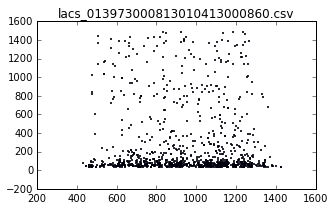

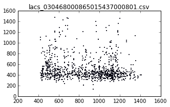

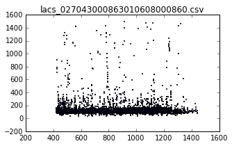

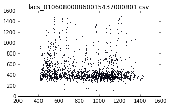

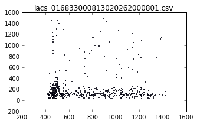

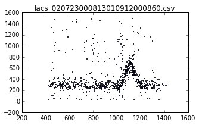

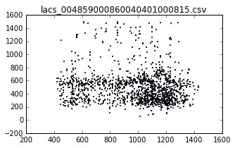

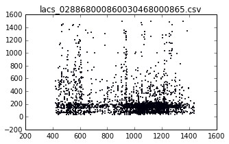

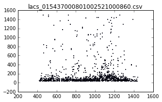

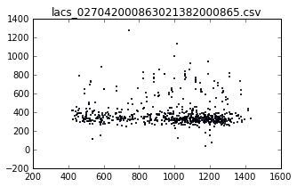

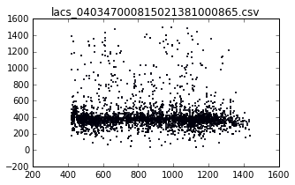

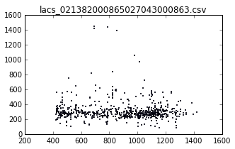

[13 more figures not shown]

Note on lacs_004859000860021279000865.csv. Visually speaking, I'm having a hard time deciding if this is a road or not. To me, it appears that the antennas are capturing at least two very different types of activities. I'm fairly sure one of those activities is driving activities on a road, perhaps it's even a highway as the time between antennas is very low. It's the lowest (aka fastest) I've seen throughout all the antenna pairs. Moreover, the line is so tight and is visually very dark indicating that perhaps this is a very often used highway by many cars or perhaps the distance between the antennas is shorter than the others which is why they're moving so fast.

However, at the same time there seems to be separate distinct activity at semi-regular intervals that don't follow the trend of a road as the scatterplot is showing vertical patterns that don't seem to match to what I think is the road or highway.

## Final table classifying the antenna pairs as road or not road.

```
finalcategory = []
```

```
for each in final4['cluster']:
```

```
    if each==0: #Take a look at the road cluster to make sure they're actually roads
```

[output not shown]

```
    elif each ==1:
```

```
        each="Not Road"
```

```
    else:
```

```
        break
```

```
    finalcategory.append(each)
```

```
final4['Road?'] = finalcategory
```

```
final4['Road?']
```

[output not shown]